# 第12回 重回帰・欠落変数バイアス・補正 R2・F 検定

経済データ入門

第12回

重回帰・欠落変数バイアス・  
補正 R2・F 検定

説明変数を増やすと、係数の読み方が変わる

経済データ入門

第12回 — Topic01

重回帰

説明変数を増やすと何が変わる？

## 前回の振り返り

前回のポイント 第11回「標準誤差・t 値・仮説検定・信頼区間」

Q: 5 人の線 12 − 2x から、何が言えたか

- **5 人**：バイトが 1 日多いと、自習の見込みが 2 時間短い
- **検定**：P-値 0.0405 ≦ 0.05。関係が無いとは考えにくい
- **P-値**：関係が無い世界で、いまの t 以上に 0 から離れた t が出る割合
- **説明に使った列**：バイト日数の 1 本だけ

今日は、説明に使う列を 2 本、3 本に増やす

## この回の道のりと「5人」シート

1

重回帰

演習 12-1

失業率だけの傾き

2

欠落変数バイアス

演習 12-2

35 年の肩代わり

3

補正 R2

演習 12-3

下 1 けたの補正 R2

4

F 検定

演習 12-4

足した列の判定

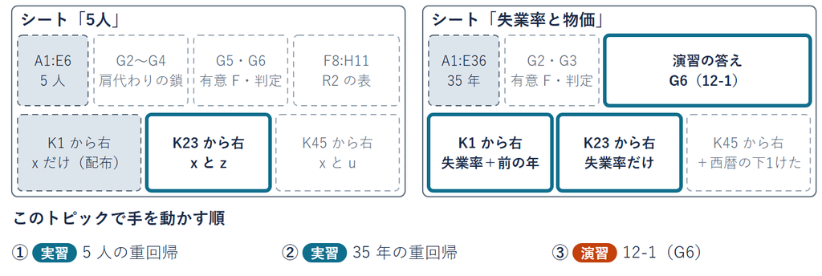

置き場は lec12-exercise.xlsx の 2 枚。説明に使う列は隣どうしに並べてある

## 説明に使う列の数

自習が減るのは、バイトのせいか、サークルのせいか

- **いまの道具**：バイト日数 1 本で、自習時間をある程度説明できた
- **足りない所**：バイトの多い人は、  
  サークルにも多く出ているかもしれない
- **知りたいこと**：2 時間のうち、  
  サークルが同じ人どうしで比べた差はどれだけか
- **そこで**：サークル日数も説明に使い、前に出てきた選び方で式を引く

## 5 人に足したサークル日数

[figure not shown]

サンプルデータ（架空）。lec12-exercise.xlsx の「5人」A1:E6  
B 列の出席番号の下1けたは、後のトピックで使う

## 説明変数と目的変数

用語

**説明変数**自習時間の違いを説明するのに使う量  
（バイト日数 x・サークル日数 z）

**目的変数**説明したい量（自習時間 y）

前の回のダイアログの X が説明変数、Y が目的変数  
この回から、x も z も「説明変数」と呼ぶ

## たしかめ バイト日数の係数

サークル日数 z も説明に入れると  
バイト日数の係数 −2.0 はどうなるか

**1**  
−2.0 のまま

**2**  
ゆるむ（0 に近づく）

**3**  
きつくなる

1 つ決めてから先へ。答えは次のページで

## 重回帰

**重回帰：説明変数を複数にした回帰分析**

定義

$$\hat{y} = \text{切片} + b_1 \times x + b_2 \times z$$

ŷ は式で出す見込み（予測値）  
b₁ は x の係数、b₂ は z の係数  
選び方は前に出てきたもの（外れの 2 乗の合計が最小）

今回は

$\hat{y}$

$= 12 - 1.0x - 2.5z$

5 人

バイト日数の係数は −2.0 から −1.0 へゆるんだ。たしかめの答えは 2 番

## サークルをそろえた比較

[figure not shown]

サークル 2 日の D と E。見込みは 12 − 4 − 5 ＝ 3 と 12 − 5 − 5 ＝ 2、差は 1 時間  
z は足し算で入るので、サークルが何日でも差は同じ。だから 3 本は平行

## 偏回帰係数

用語

**偏回帰係数**ほかの変数が同じ人どうしで  
その変数が 1 違うときの見込みの差

**−1.0**サークルが同じ人どうしなら  
バイトが 1 日多い人は見込みが 1.0 時間短い

**−2.5**バイトが同じ人どうしなら  
サークルが 1 日多い人は見込みが 2.5 時間短い

同じ「バイト日数の係数」でも、何をそろえたかで答える問いが違う

## よくある失敗 縮んだ係数の読み

**取り違え**  
−2.0 が −1.0 になった  
＝ どちらかの計算ミス

**正しい読み**  
どちらも正しい計算  
そろえたものが違う

−2.0 はサークルをそろえない比較、−1.0 はサークルをそろえた比較

## 5 人の重回帰

1. **開く**：データ → データ分析  
   → 回帰分析 → OK
2. **入れる**：Y に E1:E6  
   X に C1:D6（隣り合った 2 列）  
   ラベル・出力先 K23
3. **見る**：係数の行が 3 行  
   12・−1・−2.5

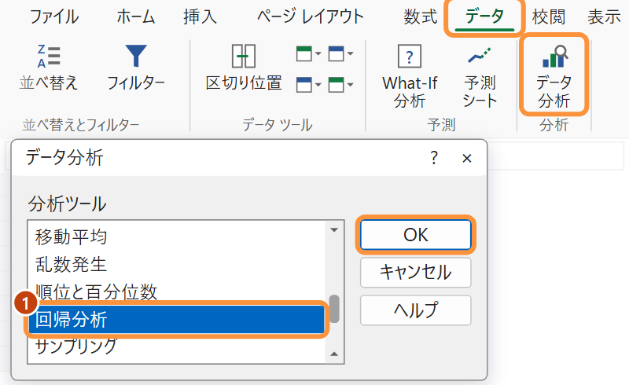

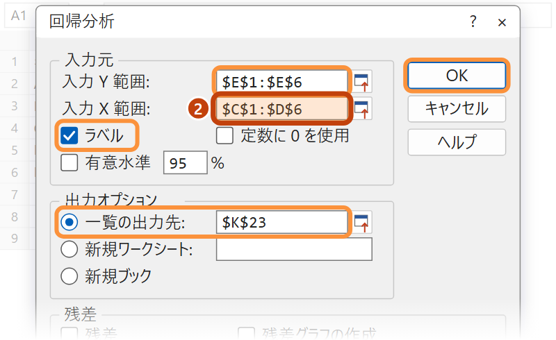

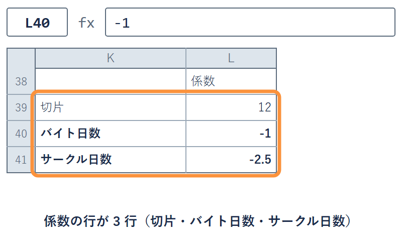

**重回帰でも道具は単回帰と同じ。違うのは入力 X 範囲で列を 2 つ選ぶ所だけ**  
Mac も「データ」タブ →「データ分析」（分析ツールを有効にしてあれば）

✋ 動画を止めて ①〜③ を進め、係数が出たら再生に戻る

## 係数の表の 3 行

[figure not shown]

式は 12 − 1.0x − 2.5z  
サークル日数を入れると、バイト日数の係数がゆるむ

## 前の年の物価上昇率

- **今度は**：前に出てきた失業率と物価上昇率で、同じことをする
- **足す列**：前の年の物価上昇率。  
  値上げは翌年も続きやすい（物価の勢い）
- **作り方**：物価上昇率の列を 1 行下へずらす。新しい統計は取ってこない
- **困ること**：1991 年は前の年が表に無い。使えるのは 35 年

**実データ**：完全失業率（労働力調査）と物価上昇率  
（消費者物価指数）の年平均  
2026 年は 1〜5 月の平均。lec12-exercise.xlsx  
「失業率と物価」の A1:E36  
C 列は作ってある。D 列の西暦の下1けたは、後のトピックで使う

## 1 行下へずらした列

[figure not shown]

1992 年の行に 1991 年の 2.88。1991 年の行が欠けて 35 年（1992〜2026 年）  
2026 年の行の前の年は、2025 年の 12 か月の平均

## 35 年の重回帰

1. **並び**：説明に使う B と C は  
   隣どうし（配ってある）
2. **入れる**：Y に E1:E36  
   X に B1:C36・ラベル・出力先 K1
3. **見る**：失業率 −0.516  
   前の年の物価上昇率 0.381

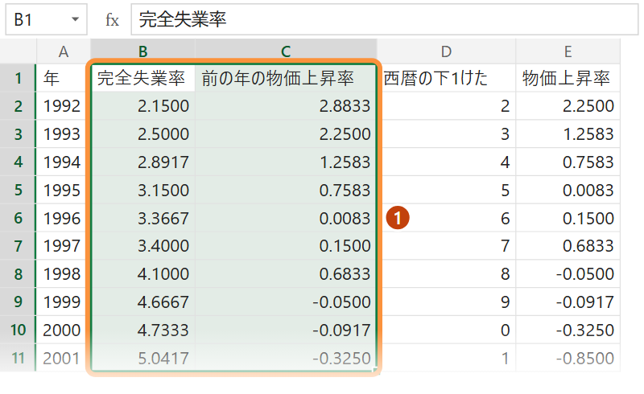

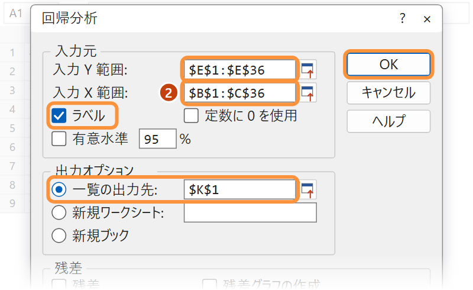

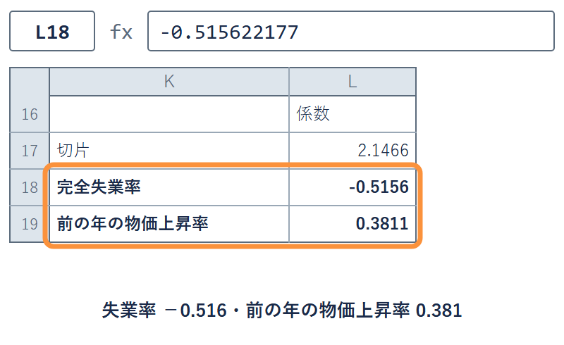

✋ 動画を止めて ①〜③ を進め、係数が出たら再生に戻る

## 35 年の係数の読み

読み

**−0.516**前の年の物価上昇率が同じなら  
失業率が 1 ポイント高い年は  
物価上昇率が約 0.52 ポイント低い

**0.381**失業率が同じなら  
前の年の物価上昇率が 1 ポイント高い年は  
物価上昇率が約 0.38 ポイント高い

式は 2.147 − 0.516 × 失業率 ＋ 0.381 × 前の年の物価上昇率  
係数を読むときは、そろえたものを必ず添える

## 演習 12-1 失業率だけの傾き

演習 12-1

失業率だけで回すと、失業率の係数はいくつか

1. **開く**：「失業率と物価」で データ → データ分析 → 回帰分析
2. **範囲**：**実データ**の Y に E1:E36、X は失業率の列だけ（範囲は自分で決める）・ラベル
3. **出力先**：「一覧の出力先」に K23。失業率の係数は L40
4. **答え**：L40 を小数第 3 位まで G6 に数字で打ち、−0.516 と比べる

✋ 動画を止めて演習 12-1 を進め、G6 に打ったら再生に戻る

## 2 本の係数の棒

[figure not shown]

演習 12-1 の答えは −0.810。前の年の物価上昇率を入れると −0.516

## Q&A 重回帰

Q1 入力 X 範囲に、離れた 2 列を指定した

分析ツールは**隣り合った列**だけ受け付ける。  
配った並び（C:D・B:C）を使う

Q2 係数の行が 2 行しか出ない

入力 X 範囲が 1 列になっている。**C1:D6** のように 2 列を指定する

Q3 観測数が 35 にならない

Y と X の範囲の行をそろえる。**1〜36 行目**（見出しの 1 行と 35 年）

## まとめ

- **重回帰**：説明変数を複数にした回帰分析
- **偏回帰係数**：ほかの変数が同じ人どうしで、  
  その変数が 1 違うときの見込みの差（5 人で −1.0）
- **35 年**：前の年の物価上昇率をそろえると、失業率の係数は −0.516
- **ツール**：入力 X 範囲は隣り合った列

列を足すと −2.0 は −1.0 に、−0.810 は −0.516 に縮んだ。なぜか  
これを次のトピックで見る

経済データ入門

第12回 — Topic02

欠落変数バイアス

入れ忘れた列の分は、どこへ行く？

## この回の道のりと「5人」シート

1

重回帰

演習 12-1

失業率だけの傾き

2

欠落変数バイアス

演習 12-2

35 年の肩代わり

3

補正 R2

演習 12-3

下 1 けたの補正 R2

4

F 検定

演習 12-4

足した列の判定

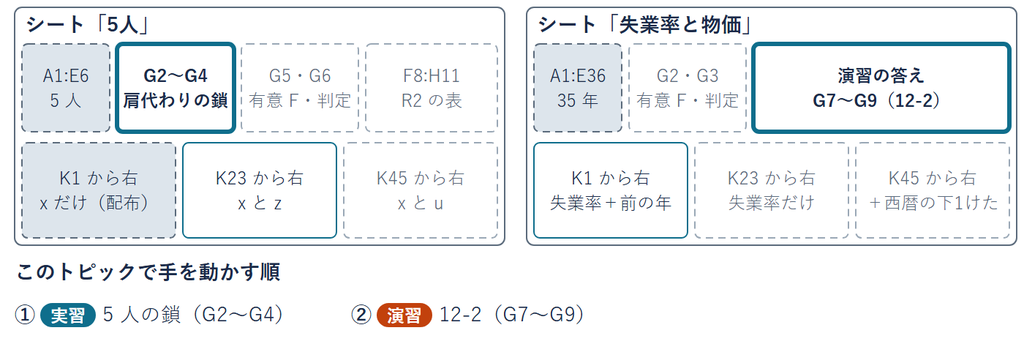

置き場は「5人」の G2〜G4 と「失業率と物価」の G7〜G9

## 消えた −1.0

[figure not shown]

サークル日数を入れると、バイト日数の係数が −2.0 から −1.0 に縮んだ  
消えた −1.0 は、どこへ行ったのか

## 消えた分の行き先

- **いまの道具**：2 つの係数 −2.0 と −1.0。どちらも正しい計算
- **困ること**：バイトが 1 日少ない人の見込みを言うのに、どちらを使うか
- **知りたいこと**：消えた −1.0 の行き先
- **そこで**：バイトとサークルが同じ向きに動くかを、数にする

## たしかめ バイトとサークルの向き

バイトが 1 日多い人は、サークル日数はどうか

**1 多い**

**2 少ない**

**3 変わらない**

1 つ決めてから先へ。答えは次のページで

## バイトとサークルの散布図

[figure not shown]

前の回の SLOPE（最小二乗の線の傾きを出す関数）と同じ線

相関係数 0.756。たしかめの答えは 1 番

## 付いてくるサークルの分

付いてくる日数

$0.4$

バイト 1 日でサークル 0.4 日

サークルの効き

$-2.5$

バイトが同じなら、  
サークル 1 日で −2.5 時間

付いてくる分

$0.4 \times (-2.5)$

$= -1.0$

バイト 1 日あたりの時間

「バイト 1 日あたりサークル 0.4 日」×「サークル 1 日あたり自習 −2.5 時間」  
＝「バイト 1 日あたり自習 −1.0 時間」。サークルの日が消える  
−2.5 は T1 で出した重回帰のサークル日数の係数（L41）

## バイトの係数の内訳

[figure not shown]

バイトだけの −2.0 ＝ サークルをそろえた係数 −1.0  
＋ 付いてくるサークルの分 −1.0

そろえた係数は、サークルが同じ人どうしの差

## 欠落変数バイアス

**欠落変数バイアス：入れ忘れた列の分を、入れた列が肩代わりする**

定義

$$\textbf{1 列だけの傾き} = \textbf{そろえた係数} + \textbf{付いてくる量} \times \textbf{忘れた列の係数}$$

付いてくる量：使った列 1 あたり、入れ忘れた列が平均いくつ増えるか（5 人 0.4）  
忘れた列の係数：両方入れた重回帰での、入れ忘れた列の係数（5 人 −2.5）

今回は

$-2.0$

$= -1.0 + 0.4 \times (-2.5)$

5 人

バイトだけの −2.0 は、サークルの分 −1.0 まで肩代わりしていた

## 肩代わりで困ること

- **疑問**：肩代わりしてくれるなら、バイトだけで十分では
- **−2.0 の比較**：バイトが 1 日少ない人は、見込みが 2 時間長い  
  ただしサークルも違う人どうしの比較
- **サークルが同じ人どうし**：見込みは 1 時間長いだけ。2 倍に見ていた

今回はサークルが同じ人どうしで比べたいので、サークルの列を入れる

## よくある失敗 本当の効果の取り違え

**取り違え**  
サークルを入れた −1.0 が  
バイトの本当の効果

**正しい読み**  
入れた列をそろえたら −1.0  
入れていない列の分は残る

通学時間・授業の数など、入れていない列があれば肩代わりはまだ残る

## 5 人の肩代わりの鎖

1. **付いてくる日数**：G2 に  
   `=SLOPE(D2:D6,C2:C6)` → 0.4  
   （説明されるほうの D が先）
2. **掛ける**：G3 に `=G2*L41` → −1  
   （L41 は T1 で K23 に出した係数）
3. **足す**：G4 に `=L40+G3` → −2  
   （バイトだけの傾き・K1 の L18）

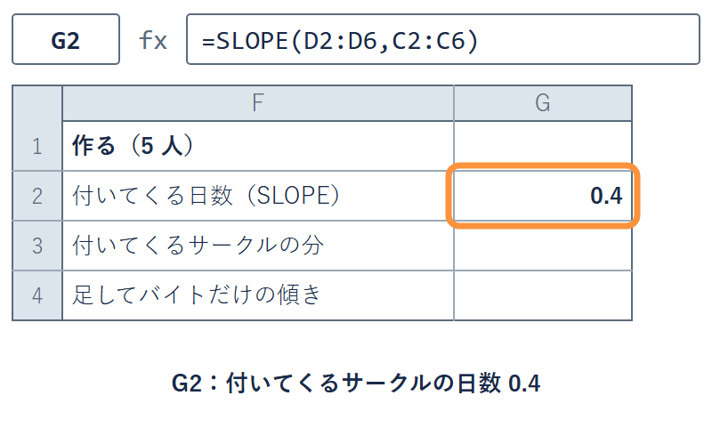

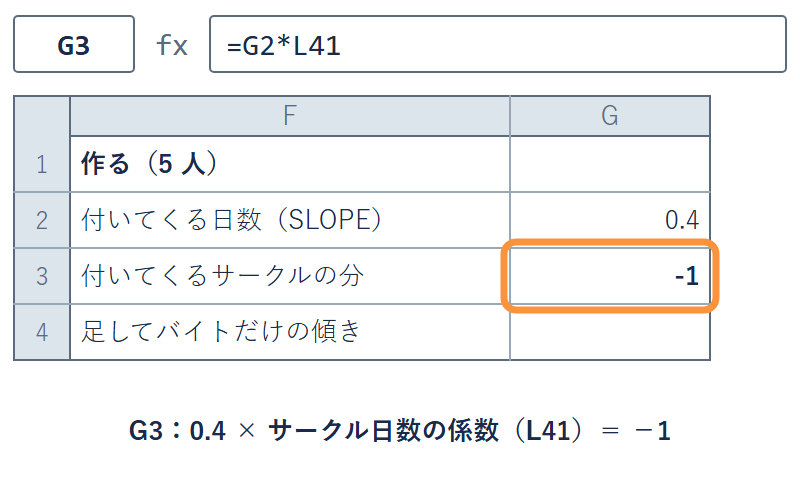

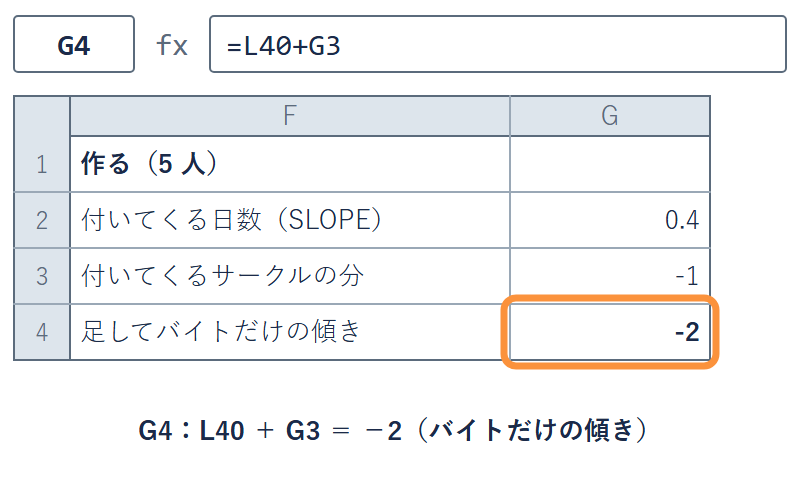

✋ 動画を止めて ①〜③ を進め、−2 が出たら再生に戻る

## 35 年の肩代わり

- **今度は**：35 年で同じ 2 歩
- **一歩 1**：前の年の物価上昇率を、失業率で説明する線の傾き  
  （原因の向きは問わない。そろって動く度合いを測る線）
- **一歩 2**：その傾き × 前の年の物価上昇率の係数 0.381
- **場面**：不景気は何年か続くので、失業率の高い年は  
  前の年の物価上昇率も低かったか

## 失業率と前の年の物価上昇率の散布図

[figure not shown]

失業率が 1 ポイント高い年は、  
前の年の物価上昇率が平均で 0.772 ポイント低い

## 35 年の鎖

掛ける

$-0.772 \times 0.381$

$\approx -0.294$

物価の勢いの分

足す

$-0.810$

$= -0.516 + (-0.294)$

失業率だけの傾き

失業率が高い年は前の年の物価上昇率も低く、その低さが今年と一緒に動く

失業率だけの −0.810 は、その分 −0.294 まで肩代わりしていた

## 35 年の肩代わりの棒

[figure not shown]

5 人と同じ形。足し算がぴったり合う

## 演習 12-2 35 年の肩代わりの鎖

演習 12-2

35 年で、肩代わりの鎖を自分のシートで確かめる

1. **付いてくる量**：**実データ**の G7 に `=SLOPE(C2:C36,B2:B36)`（説明されるほうの C が先）
2. **掛ける**：G8 に、5 人の G3 にならって式を組む（使う番地は G7 と L19）
3. **足す**：G9 に、5 人の G4 にならって式を組む（使う番地は L18 と G8）
4. **比べる**：G9 と演習 12-1 の G6 を、小数第 3 位まで比べる

✋ 動画を止めて演習 12-2 を進め、G9 が出たら再生に戻る

## この授業の外で 考慮という言い方

- **家賃と駅からの距離**：駅から遠い部屋は広いことが多い  
  広さをそろえないと、遠い分の安さが小さく見える
- **賃金の差**：勤続年数をそろえて比べる
- **記事や白書**：「〜を考慮すると」「〜の影響を除くと」がこれ

そろえていない比較を見たら、入れ忘れた列を疑う

## Q&A 欠落変数バイアス

Q1 G2 が 0.4 にならない

SLOPE は **説明されるほう（D）が先**。`=SLOPE(D2:D6,C2:C6)`

Q2 G4 が −2 にならない

掛けるのはサークル日数の係数 **L41**、足すのはバイト日数の係数 **L40**  
L41 が空なら、T1 の実習（K23 の重回帰）から

Q3 35 年の鎖が −0.810 にならない

失業率だけの出力も、  
**見出しを含む 1〜36 行目**を選び、ラベルにチェック

## まとめ

- **付いてくる日数**：バイトが 1 日多い人は、サークルも平均で 0.4 日多い
- **付いてくる分**：0.4 ×（−2.5）＝ −1.0
- **欠落変数バイアス**：入れ忘れた列の分を、入れた列が肩代わりする
- **35 年**：−0.810 ＝ −0.516 ＋（−0.294）

入れる列で、係数が変わる。では列は多いほどよいか  
これを次のトピックで見る

経済データ入門

第12回 — Topic03

補正 R2

関係の無い列でも、R² は上がる

## この回の道のりと「5人」シート

1

重回帰

演習 12-1

失業率だけの傾き

2

欠落変数バイアス

演習 12-2

35 年の肩代わり

3

補正 R2

演習 12-3

下 1 けたの補正 R2

4

F 検定

演習 12-4

足した列の判定

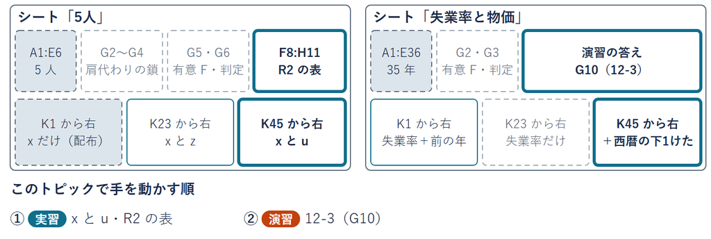

置き場は「5人」の K45 と F8:H11、「失業率と物価」の K45 と G10

## 列の数と当てはまり

- **いまの道具**：R²（平均だけの見込みの外れが、線で何割消えたか）
- **足りない所**：列を入れれば肩代わりは防げる。では多いほどよいか  
  実データでは、どの列が関係無いかは前もって分からない
- **知りたいこと**：関係の無い列を足しても、R² は上がるのか
- **そこで**：関係があると考える理由の無い列を、わざと足す

## 関係の無い列 u

[figure not shown]

出席番号の下 1 けた u。自習と関係が無いように作ったサンプルの列

## たしかめ u を足した R²

バイト日数に u を足すと、R² 0.80 はどうなるか

**1 下がる**

**2 変わらない**

**3 上がる**

1 つ決めてから先へ。答えは次のページで

## 3 本の R²

[figure not shown]

関係の無い u でも上がった。たしかめの答えは 3 番

## 列を足した R²

- **疑問**：関係の無い列で上がるのは、Excel のおかしな所では
- **答え**：u の係数を 0 にすれば x だけの線と同じ。少なくとも 0.80 は出せる  
  少しでも外れが減る係数があれば、そちらを選ぶ
- **決まり**：列を足して R² が下がることはない
- **困ること**：この 5 人の偶然の並びに合わせただけ。  
  6 人目の自習時間は当たらない
- **そこで**：外れを、自由に動ける外れの数で割ってから比べる  
  平均だけの見込みは 5 − 1、x と u の線は 5 − 2 − 1

## 補正 R2

**補正 R2：関係の無い列でも R² は上がる。その分を差し引いて比べる**

定義

$$\textbf{補正 R2} = 1 - (1 - R^2) \times \frac{\textbf{点の数} - 1}{\textbf{点の数} - \textbf{説明変数の数} - 1}$$

説明変数の数 ＝ X に入れた列の数（Y と切片は数えない）。x と u なら 2

消え残り

$1 - 0.85$

$= 0.15$

x と u の外れの割合

倍率

$4 \div 2$

$= 2$

(5 − 1) ÷ (5 − 2 − 1)

2 倍に見る

$0.15 \times 2$

$= 0.30$

消え残りを 2 倍に見る

引く

$1 - 0.30$

$= 0.70$

補正 R2

## 補正 R2 の式の部分

用語

**1 − R²**線でも消え残った外れの割合

**割る数**点の数 − 決める数（切片と説明変数）  
＝ 自由に動ける外れの数（x と u なら 2）

**4**平均だけの見込みは 1 つ決めるので 5 − 1

**倍率**4 ÷ 割る数。列を足すほど上がる（約 1.33 倍・2 倍）

x だけ

$1 - 0.20 \times 4 \div 3$

$\approx 0.733$

倍率 約 1.33

x と z

$1 - 0.05 \times 4 \div 2$

$= 0.900$

倍率 2

## 3 本の補正 R2

[figure not shown]

出力表では「重決定 R2」が R²、その下の「補正 R2」がこの数

## よくある失敗 下がった補正 R2 の読み

**取り違え**  
補正 R2 が下がった  
＝ 無関係だと証明できた

**正しい読み**  
この 5 人では  
足しても割に合わなかった

本当は関係がある列でも、点が少なければ下がることはある  
関係の有無を問うなら、その列の P-値を見る

## 5 人の x と u の重回帰

1. **回す**：データ分析 → 回帰分析  
   Y に E1:E6、X に B1:C6（出席番号と  
   バイト）・ラベル・出力先 K45
2. **見る**：重決定 R2 0.85  
   補正 R2 0.7（L49・L50）
3. **並べる**：F8:H11 に 3 本  
   左上 ＋4 行が R2  
   ＋5 行が補正 R2（G9 `=L5`）

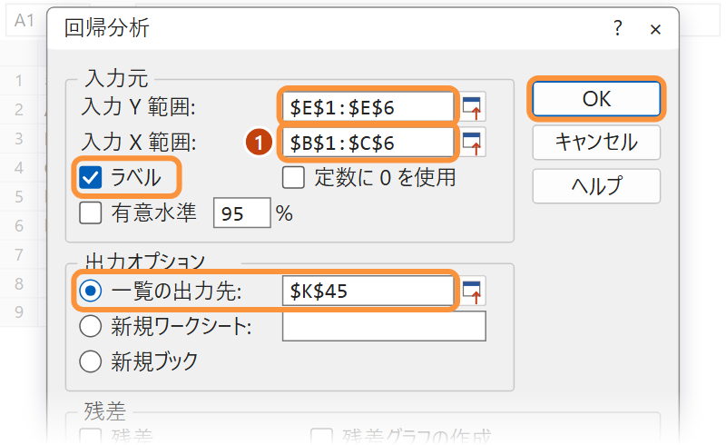

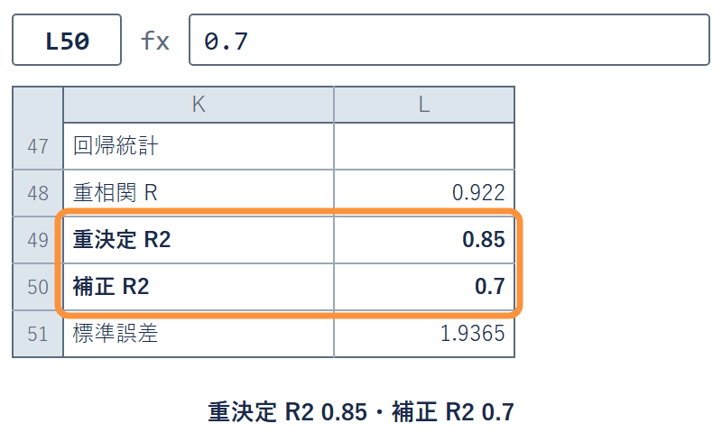

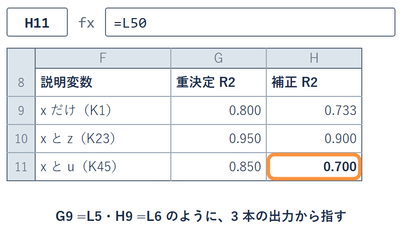

✋ 動画を止めて ①〜③ を進め、表ができたら再生に戻る

## 西暦の下 1 けたの列

- **今度は**：35 年で同じことをする
- **足す列**：西暦の下 1 けた（1992 年なら 2、2026 年なら 6）
- **関係**：物価と関係があると考える理由の無い列
- **比べる相手**：失業率と前の年の物価上昇率の R² 0.605・補正 R2 0.580

## 演習 12-3 西暦の下 1 けたの補正 R2

演習 12-3

西暦の下 1 けたを足すと、補正 R2 は上がるか下がるか

1. **開く**：「失業率と物価」で データ → データ分析 → 回帰分析
2. **範囲**：**実データ**の Y に E1:E36、X に B1:D36（隣どうしの 3 列）・ラベル
3. **出力先**：「一覧の出力先」に K45。補正 R2 は L50
4. **答え**：L50 を小数第 3 位まで G10 に数字で打ち、K1 の出力の L6（0.580）と比べる

✋ 動画を止めて演習 12-3 を進め、G10 に打ったら再生に戻る

## 35 年の R² と補正 R2

[figure not shown]

演習 12-3 の答えは 0.572

（K1 の 0.580 から 0.008 下がる）

## Q&A 補正 R2

Q1 補正 R2 がマイナスになった

点が少なく列が多いと起きる。**割に合わない印**として読む

Q2 1 年足した 36 年の式と 35 年の式で R² を比べた

R² を比べてよいのは、**同じ年の並び（同じ行）**  
で同じ目的変数を説明した式どうし

Q3 X に 3 列が入らない

**B1:D36** のように、左上から右下まで 1 つの範囲で指定する

## まとめ

- **R²**：列を足すと下がらない（関係の無い u でも 0.80 → 0.85）
- **補正 R2**：足した列の数に応じて差し引く（0.733・0.900・0.700）
- **読み方**：下がった ＝ 割に合わなかった。無関係の証明ではない
- **35 年**：西暦の下 1 けたで 0.580 → 0.572

5 人しかいないのに線が合ったのは、たまたまではないか  
これを次のトピックで見る

経済データ入門

第12回 — Topic04

F 検定

変数全体をまとめて判定する

## この回の道のりと「5人」シート

1

重回帰

演習 12-1

失業率だけの傾き

2

欠落変数バイアス

演習 12-2

35 年の肩代わり

3

補正 R2

演習 12-3

下 1 けたの補正 R2

4

F 検定

演習 12-4

足した列の判定

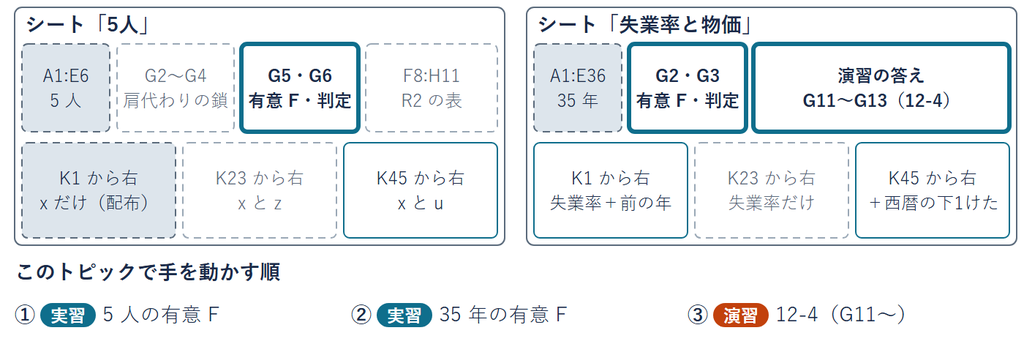

置き場は「5人」の G5・G6、「失業率と物価」の G2・G3 と G11〜G13

## まとめて確かめる理由

- **疑う人**：5 人に 2 本も列を入れたら、R² 0.85 は当たり前では
- **いまの道具**：前の回の t 検定は、係数を 1 つずつ確かめる
- **困ること**：1 つずつ確かめると、偶然の当たりを引く見込みが増える  
  （2 本が互いに関係しないなら約 1 割）
- **そこで**：列を全部まとめて、1 回で確かめる

## 仮説検定の 3 段

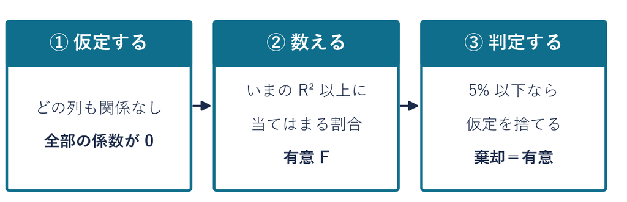

前の回と同じ 3 段。数える物を、t から当てはまりの R² に替える  
R² なら、列が何本あっても当てはまり全体が 1 つの数

## ① 仮定

**仮定：どの列も関係ない（説明変数の係数がどれも 0）**

- **作り方**：自習時間を、x にも u にも関係なく、でたらめに散らばらせる
- **外れの大きさ**：前の回の作り直しと同じ  
  線を平らに（係数を全部 0 に）して、外れだけ引き直す
- **数える物**：そのたびに x と u で重回帰を引いた R²

## たしかめ 関係なしの世界の R²

関係なしの世界で 5 人を 1000 回作り直す  
R² が手元の 0.85 以上になるのは何回くらいか

**1**  
約 15 回

**2**  
約 150 回

**3**  
約 500 回

1 つ決めてから先へ。答えは次のページで

## 関係なしの世界の R² の山

[figure not shown]

R² は 0 から 1 にほぼ平らに散らばった

たしかめの答えは 2 番

## ② 数える

山の右、手元の 0.85 以上は 1000 回のうち 149 回

割合

$149 \div 1000$

$= 0.149$

0.85 以上の割合

関係が無くても、いまの R² 以上が出る割合

## ③ 判定

② で数えた割合 0.149 を、5% と比べる

比べる

$0.149 > 0.05$

5% より大きい

仮定は捨てない（「たまたま」の可能性を消せない）

関係が無くても、約 7 回に 1 回は出る当てはまり  
関係が無いと示したわけではない

## F 検定

**F 検定：列を全部まとめて、偶然だけで説明できるかを判定する**

用語

**有意 F**関係なしの世界で、いまの R² 以上の割合  
（② で数えた 0.149 にあたる）

**F 値**説明できた分（1 列あたり 21.25）が  
残った外れ（1 個あたり 3.75）の何倍か  
5 人は 5.67 倍。出力表では「観測された分散比」

**判定**5% 以下なら「関係なし」を捨てる

F 値の作り方は、配布資料の付録にくわしく書いた

## 出力表の有意 F

[figure not shown]

有意 F は 0.15。数えた 0.149 とほぼ同じ

x だけなら 0.0405（前の回の P-値）。関係の無い u を足すと 0.15

## 上の段と下の段

[figure not shown]

全体が有意でも、どの列が効いているかは下の段で 1 本ずつ見る

## F 値・t 値・P 値の関係

[figure not shown]

数える物を割合に直し、割合が 0.05 以下なら「関係なし」を捨てる

## 5 人の有意 F と判定

1. **見る**：K45 の出力の分散分析表  
   「回帰」の行（56 行目）
2. **印**：有意 F の P56 を塗る
3. **判定**：G5 に `=P56`、G6 に文で  
   「0.15 は 0.05 より大きいので  
   捨てない」

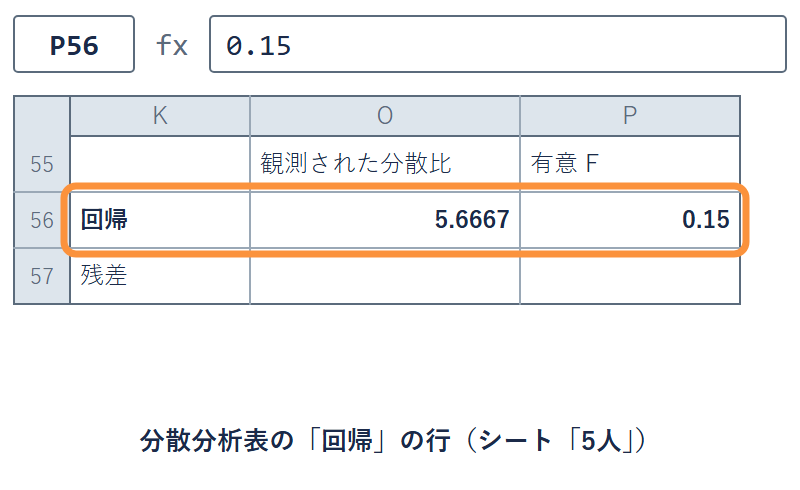

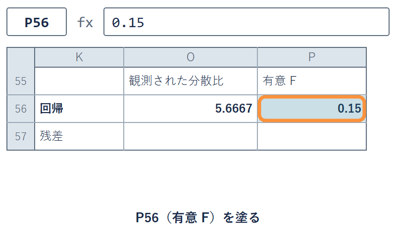

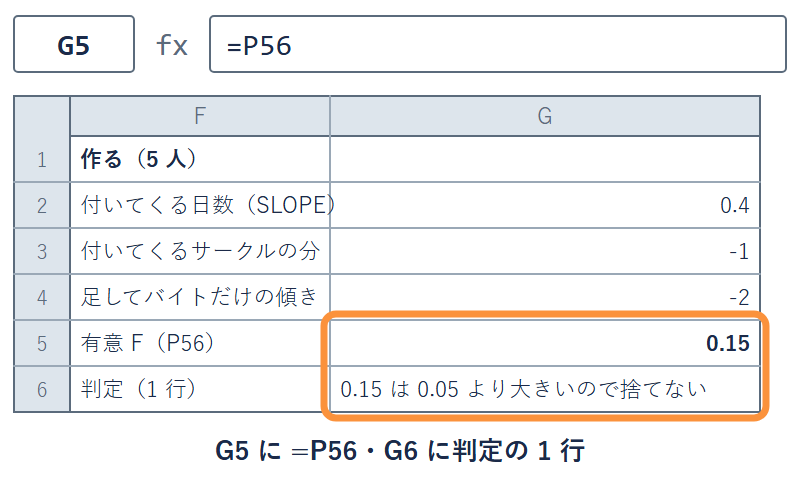

✋ 動画を止めて ①〜③ を進め、判定を書いたら再生に戻る

## 35 年の F 検定

- **今度は**：35 年の失業率と前の年の物価上昇率（K1 の出力）
- **上の段**：有意 F 3.51448E-07・F 値 24.5  
  E-07 は小数点を左へ 7 つ ＝ 0.00000035…（約 3.5×10<sup>−7</sup>）
- **判定**：5% よりずっと小さい。「どちらの列も関係なし」を捨てる
- **下の段**：P-値は失業率 0.004・前の年の物価上昇率 0.010

## 35 年の有意 F と判定

1. **見る**：K1 の出力の分散分析表  
   「回帰」の行（12 行目）
2. **印**：有意 F の P12 を塗る
3. **判定**：G2 に `=P12`、G3 に文で  
   「0.05 以下なので捨てる  
   （有意）」

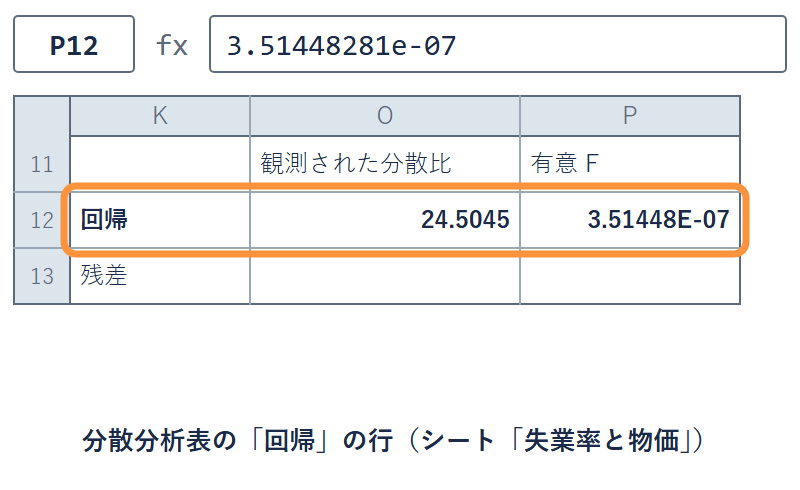

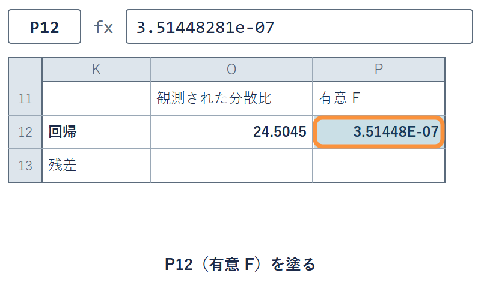

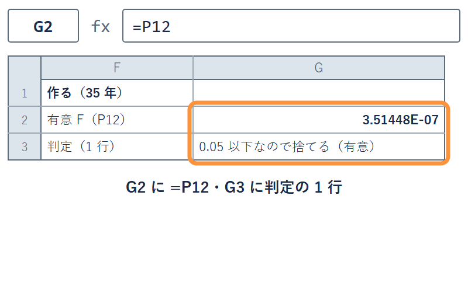

✋ 動画を止めて ①〜③ を進め、判定を書いたら再生に戻る

## 演習 12-4 足した列の判定

演習 12-4

西暦の下 1 けたを足した式で、全体とその列を判定する

1. **使う**：**実データ**の「失業率と物価」、演習 12-3 の K45 の出力
2. **全体**：有意 F の P56 を、2 けたで G11 に打つ（E の形のまま打つ）
3. **1 本**：西暦の下1けたの行の P-値 O64 を、小数第 3 位まで G12 に打つ
4. **判定**：G13 に、全体とその列の判定を記号を使わず文で 1 行

✋ 動画を止めて演習 12-4 を進め、G13 に書いたら再生に戻る

## 35 年の 2 つの式

| 説明変数 | 補正 R2 | 有意 F | 足した列の P-値 |
| --- | --- | --- | --- |
| 失業率と前の年の 物価上昇率 | 0.580 | 3.51448E-07 | 0.010（前の年） |
| ＋西暦の下1けた | 0.572 | 1.67593E-06 | 0.542（下1けた） |

全体はどちらも有意。足した西暦の下 1 けたは有意でない  
演習 12-4 の答えは 1.7×10<sup>−6</sup> と 0.542

## Q&A F 検定

Q1 有意 F が 3.51448E-07 と出た

エラーではない。小数点を左へ 7 つずらす＝**0.000000351…**

Q2 5 人の x と z で、係数の P-値が 0.205 と 0.134

5 人は**仕組みを見るための例**。判定を本気で使うのは、  
35 年のように点の多いデータ

Q3 有意 F が見つからない

**分散分析表**の「回帰」の行の右端。係数の表の P-値とは別

## この回のまとめ

用語

重回帰説明変数を複数にした回帰分析

欠落変数バイアス入れ忘れた列の分を  
入れた列が肩代わりする

補正 R2割に合うかは、差し引いた R² で比べる

F 検定まとめては有意 F（F 値から）  
1 本ずつは P-値（t 値から）

出力表の読み方：係数・補正 R2・有意 F・P-値